# Final project draft 2

Zoe Li

2024-11-16

# Introduction

The Behavioral Risk Factor Surveillance System (BRFSS) is one of the largest health surveys conducted in the U.S., coordinated by the Centers for Disease Control and Prevention (CDC). It gathers data on health-related risk behaviors, chronic health conditions, and the use of preventive services among adults across all 50 states. The BRFSS conducts annual landline and mobile phone surveys with individuals aged 18 and older. This data analysis aims to utilize Adverse Childhood Experience (ACE) data from the 2020 BRFSS dataset to explore the relationship between ACEs and adult mental health outcomes.

```r
here::i_am("code/Final_project_2.Rmd")
```

```
## here() starts at /Users/liyujou/Documents/fall2024/Data550/final_project
```

```r
data <- readRDS(
  file = here::here("derived_data/data_clean.rds")
)
```

# Table for demographics

```r
summary_table <- readRDS(
  file = here::here("output/table_one.rds")
)
summary_table
```

```
##   variable value  count proportion
## 1    EDUCA     0  84645  0.6587416
## 2    EDUCA     1  43850  0.3412584
## 3  EMPLOY1     0 103388  0.8046072
## 4  EMPLOY1     1  25107  0.1953928
## 5  INCOME2     0  81280  0.6325538
## 6  INCOME2     1  47215  0.3674462
## 7  MARITAL     0  85178  0.6628896
## 8  MARITAL     1  43317  0.3371104
```

# Logistic regression

```r
logistic_regression <- readRDS(
  file = here::here("output/logistic_regression.rds")
)
logistic_regression
```

```
##
## Call:  glm(formula = ADDEPEV3 ~ ACEDEPRS + ACEDRINK + ACEDRUGS + ACEPRISN +
##     ACEDIVRC + ACEPUNCH + ACEHURT1 + ACESWEAR + ACETOUCH + ACETTHEM +
##     ACEHVSEX + MARITAL + EDUCA + EMPLOY1 + INCOME2, family = binomial(),
##     data = data)
##
## Coefficients:
## (Intercept)     ACEDEPRS     ACEDRINK     ACEDRUGS     ACEPRISN     ACEDIVRC
##    -2.38765      1.10566      0.25543      0.04355     -0.12071     -0.04031
##    ACEPUNCH     ACEHURT1     ACESWEAR     ACETOUCH     ACETTHEM     ACEHVSEX
##    -0.03515      0.15482      0.42631      0.51075      0.18806      0.28636
##     MARITAL        EDUCA      EMPLOY1      INCOME2
##     0.23485     -0.07291      0.71321      0.27164
##
## Degrees of Freedom: 128494 Total (i.e. Null);  128479 Residual
## Null Deviance:       124800
## Residual Deviance: 109900    AIC: 110000
```

# Data visualization

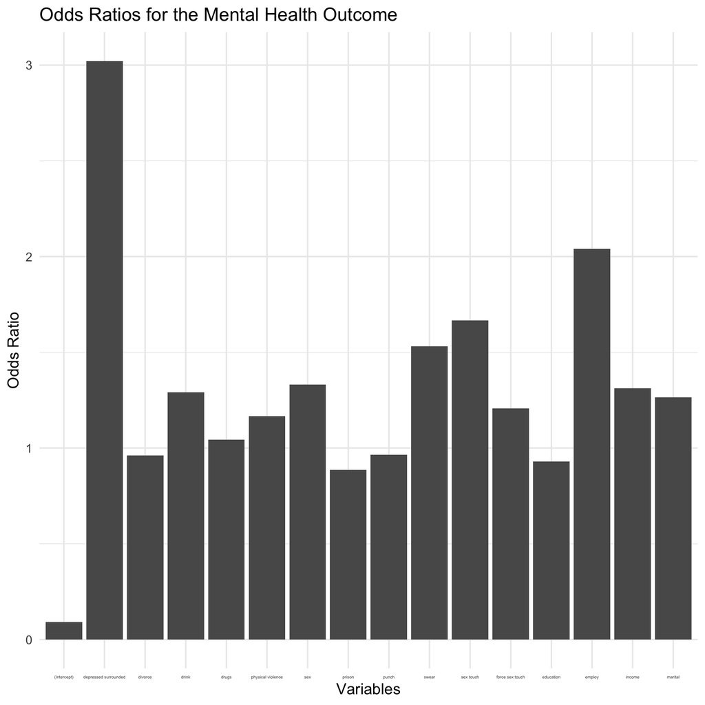

```r
knitr::include_graphics(
  here::here("output/bar_chart.png")
)
```

## Figure description

The bar chart for the logistic regression displays the odds ratios for the variables in relation to mental health outcome. Marital status, education level, employment status, and annual household income were included as covariates to reduce bias in the results. According to the chart, most adverse childhood experiences are associated with a higher likelihood of developing mental health issues compared to individuals without such experiences. Among these, growing up surrounded by family members with depression appears to have the strongest impact on children’s mental health.